# Week1: Linear Models

# Objective

This homework sheet will help reviewing the basic concepts associated with linear regression models. Please review the lectures, suggested readings, and additional resources **before** getting started on the HW

**Some questions in this assignment will require you to conduct independent research beyond the material covered in the recorded content.**

**Questions**

This homework is divided into two main parts. First, a conceptual component will review the basic concepts related to linear models. The second part of the homework is mostly intended to be a brief introduction to fitting and analyzing linear models in Python. Several of these questions are modified from James et al. (2021).

Marks Distribution

| Question | Marks |
| --- | --- |
| 1 | 1 |
| 2a | 0.25 |
| 2b | 0.25 |
| 2c | 0.25 |
| 2d | 0.25 |
| 3a | 0.25 |
| 3b | 0.25 |
| 3c | 0.25 |
| 3d | 0.25 |
| 4a.i | 0.25 |
| 4a.ii | 0.25 |
| 4a.iii | 0.25 |
| 4a.iv | 0.50 |
| 4a.v | 0.25 |
| 4a.vi | 0.50 |
| 4b | 0.50 |
| 4c | 0.50 |
| 5a | 0.25 |
| 5b | 0.25 |
| 5c.i | 0.25 |
| 5c.ii | 0.25 |
| 5c.iii | 0.25 |
| 5d | 0.25 |
| 5e | 0.25 |
| 5f | 0.25 |
| 6a | 0.25 |
| 6b | 0.25 |
| 6c | 0.25 |
| 6d | 0.25 |
| 6e | 0.25 |
| 6f | 0.25 |
| 6g | 0.50 |
| 6h | 0.50 |
| 6i | 0.50 |
| 6j | 0.50 |
| 7a | 0.25 |
| 7b | 0.50 |
| 7c | 0.50 |
| 7d | 0.25 |
| 7e | 0.25 |
| 7f | 0.25 |
| 7g | 0.50 |
| 8 | 1 |

The following website has access to the relevant datasets from the recommended textbook: https://book.huihoo.com/introduction-to-statistical-learning/data.html

# Conceptual

## Question 1

Describe the null hypotheses to which the *p*-values given in the table (see below). Explain what conclusions you can draw based on these p-values. Your explanation should be phrased in terms of sales, TV, radio, and newspaper, rather than in terms of the coefficients of the linear model.

|  | Coefficient | Std. error | t-statistics | p-value |
| --- | --- | --- | --- | --- |
| Intercept | 2.939 | 0.3119 | 9.42 | <0.0001 |
| TV | 0.046 | 0.0014 | 32.81 | <0.0001 |
| Radio | 0.189 | 0.0086 | 21.89 | <0.0001 |
| Newspaper | -0.001 | 0.0059 | -0.18 | 0.8599 |

The null hypotheses is that: $H_{0} = β_{1} = β_{2} = β_{2} = $0

for which each β correspond to the variable on the table (tv, radio and newspaper). As the first two p-value of each predictor is virtually zero we can conclude that those two variables are statistically significant.

On the other hand, the p-value for newspaper is `0.8599`, which is quite large. As the p-value for newspaper is quite high and we fail to reject the null hypothesis so we can conclude that there is no significant relationship between sales and newspaper ads.

The null hypotheses for the p-values in the table correspond to the assumption that there is no significant relationship between sales and each of the advertising mediums: TV, radio, and newspaper.

Based on the p-values given in the table:

TV: The p-value for TV is less than 0.0001, which is significantly small. This provides strong evidence to reject the null hypothesis for TV. Hence, we can conclude that there is a significant positive relationship between sales and TV advertising.

**Radio**: Similarly, the p-value for radio is also less than 0.0001, indicating strong evidence against the null hypothesis for radio. This suggests a significant positive relationship between sales and radio advertising.

Newspaper: On the other hand, the p-value for newspaper is 0.8599, which is quite large. This provides weak evidence against the null hypothesis, and hence, we fail to reject it. This suggests that there is no significant relationship between sales and newspaper advertising.

In conclusion, the sales appear to be significantly influenced by advertising on TV and radio, but not on newspaper. In conclusion, the sales appear to be significantly influenced by advertising on TV and radio, but not on newspaper.  This conclusion is based on the p-values associated with each advertising medium in the given table.

## Question 2

Assume that you collected a dataset of 100 observations containing a single predictor and a quantitative response. Then, you decided to fit a

(i) linear regression model to the data, as well as a separate

(ii) cubic regression, i.e. $Y = β_{0} + β_{1}X^{1} + β_{2}X^{2} + β_{3}X^{3} + ϵ$

### a) Suppose that the true relationship between $X$ and $Y$ is linear, i.e. $Y = β_{0} + β_{1}X + ϵ$. Consider the training residual sum of squares (*RSS*) for the linear regression, and also the training *RSS* for the cubic regression. Would we expect one to be lower than the other, would we expect them to be the same, or is there not enough information to tell? Justify your answer

#### Linear Relationship

Since the relationship between X and Y is linear then $Y = β_{0} + β_{1}X + ϵ$. should be correctly able to provide correct results.

#### Reason

As we know if we use the cubic regression model given as $Y = β_{0} + β_{1}X^{1} + β_{2}X^{2} + β_{3}X^{3} + ϵ$ will overfit the data as it's flexibility is higher and it'll introduce unnecessery complexity and would produce noise as we have 100 observations only and linear regression would get better trained compared to cubic as cubic model would required more training data compared to the linear model.

#### Training RSS

As a result of overfitting, the cubic regression model may fit the training data too closely, which will lead to a lower training RSS compared to the linear regression model. The cubic regression model could achieve a better fit to the training data set but it may not generalize well to new or unseen data.

### b) Answer part (a) using the test *RSS* rather than training *RSS*.

#### Linear Relationship

Since the relationship between X and Y is linear then $Y = β_{0} + β_{1}X + ϵ$. should be correctly able to provide correct results. The cubic regression model might capture unnecessary complexity that doesn't accurately represent the underlying structure of the data. This mismatch between the model complexity and the true relationship can lead to poor performance on test data.

#### Overfitting

The cubic regression model, with its higher complexity, has the capacity to fit the training data very closely, even capturing noise and random fluctuations. This overfitting phenomenon can lead to poor generalization to new, unseen data, such as the test data.

#### Generalization to Test Data

While the cubic regression model might perform very well on the training data (resulting in low training RSS), its performance on test data might not be good due to overfitting. The model might generalize poorly to new observations that do not adhere to the overfitted patterns captured in the training data.

### Linear Regression's Advantage

The linear regression model, being simpler and more aligned with the true linear relationship, is less prone to overfitting. It is better able to capture the underlying linear trend in the data and generalize well to new observations, resulting in better performance on test data.

In summary, if the test data follows the true linear relationship, we would expect the linear regression model to have lower test RSS compared to the cubic regression model. This is because the linear regression model is more likely to generalize well to new, unseen data without overfitting.

### c) Suppose that the true relationship between $X$ and $Y$ is not linear. However, we don’t know how far it is from linear. Consider the training *RSS* for the linear regression, and also the training *RSS* for the cubic regression. Would we expect one to be lower than the other, would we expect them to be the same, or is there not enough information to tell? Justify your answer.

- Since we do not know how far the true relationship is from being linear, we cannot confidently predict which model will perform better.
- The cubic regression model is more flexible and can capture non-linear relationships better than the linear regression model. If the true relationship is non-linear, the cubic regression model has the potential to provide a better fit to the data and achieve a lower training RSS.The increased flexibility of the cubic regression model also comes with a higher risk of overfitting if actual relationship between X and Y is of lower complexity.

Without the true relationship between X and Y and how far it is from being linear, it is difficult to predict whether the training RSS for the linear regression model will be lower than that of the cubic regression model. The outcome depends on the specific characteristics of the data and the true underlying relationship, as well as the trade-off between model complexity and generalization performance. Therefore, in this scenario, there is not enough information to confidently predict which model will perform better in terms of training RSS.

### d) Answer (c) using test *RSS* rather than training *RSS.*

- If the true relationship is closer to being linear, then the linear regression model might perform better on test data. In this case, the cubic regression model might overfit the training data, capturing unnecessary complexity that does not generalize well to new observations.
- If the true relationship is highly non-linear, the cubic regression model might perform better on test data.

Without knowledge of the true relationship, it is difficult to predict with certainty how each model will perform on test data. However, there is a possibility that the linear regression model might perform better if the true relationship is closer to being linear.

## Question 3

### a) Discuss the implications that uncertainty in $X$ would have on parameter estimates based on linear regression models. Should we care about error in $X$ when fitting OLS regressions?

Linear regression assumes the independent variable (X) is measured without error. In reality, all measurements have some level of uncertainty. This uncertainty in X can lead to a phenomenon called measurement error.

**Impact on Estimates:**

**Bias:** Measurement error in X can bias the slope estimate. This is because the errors in X tend to be correlated with the errors in the dependent variable (Y). This correlation leads to an underestimation of the true slope (attenuation bias).

**Increased Variance:** Uncertainty in X adds noise to the relationship between X and Y. This additional noise increases the variance of the residuals, making it harder to detect a true relationship and leading to wider confidence intervals for the parameters.

**Should we care?** Yes, we should care about errors in X as OLS regression relies on minimizing the squared residuals. If X has errors, these errors get reflected in the residuals, leading to misleading results.

### b) Provide a brief discussion on the concept of regression dilution.

Regression dilution, also known as regression attenuation, is the `biasing of the linear regression slope towards zero` (the underestimation of its absolute value), caused by errors in the independent variable. Imagine the true relationship between X and Y is a steep line. But when you measure X, there's inherent variability or error. This measurement error creates a cloud of data points around the true line. When you fit a regression line to this data, it will tend to be shallower than the true line, underestimating the strength of the relationship.

**Why it's important:**

Regression dilution can lead to misleading conclusions about the relationship between variables. If you're not aware of it, you might miss a strong underlying effect.

### c) Are there any linear regression models that account for uncertainty in $X$ and $Y$? Please do some independent research and cite your sources.

Linear regression itself doesn't directly account for uncertainty in the independent variable (X) or the dependent variable (Y). It assumes that the independent variable is measured without error and focuses on modeling the relationship between the independent variable and the expected value of the dependent variable.

Here are some linear regression models that address uncertainty in different ways:

## 1. Measurement Error Models:

These models acknowledge that both X and Y might have measurement errors and attempt to estimate the true relationship between the underlying variables despite these errors. Here are two common approaches:

### Deming Regression:

This method assumes both X and Y have errors and estimates the slope and intercept while considering the error variances. It provides a more accurate estimate of the true relationship compared to standard linear regression when measurement errors are present.

### Interval Regression:

This approach estimates not just the expected value of Y for a given X but also a confidence interval around that prediction. This interval reflects the uncertainty in the relationship due to random errors. It provides a range of possible values for Y given X, accounting for the inherent variability in the data.

### Bayesian Linear Regression:

This method incorporates prior beliefs about the parameters (slope and intercept) into the model using probability distributions. The resulting posterior distributions account for the uncertainty in the estimated parameters. By incorporating prior knowledge, it can potentially provide more robust estimates compared to standard linear regression.

## Citations:

Buonaccorsi, John. (2010). Measurement Error: Models, Methods and Applications. Measurement Error: Models, Methods, and Applications. 10.1201/9781420066586.

**Applied regression analysis** (3rd ed.). Wiley. (Chapter 2)

### d) Distinguish between least squares and maximum likelihood in the context of linear regression models

In the context of linear regression models, both least squares estimation and maximum likelihood estimation are methods used to estimate the parameters of the model. However, they differ in their underlying principles and assumptions:

1. **Least Squares Estimation**:
   - **Objective**: The objective of least squares estimation is to minimize the sum of the squared differences between the observed dependent variable values and the values predicted by the linear regression model.
   - **Assumption**: Least squares estimation assumes that the errors (residuals) follow a normal distribution with constant variance (homoscedasticity) and are independent of each other.
   - **Optimization**: The optimization problem is formulated as minimizing the sum of squared residuals, which leads to a closed-form solution for the parameter estimates.
   - **Estimation**: The parameter estimates are obtained by solving the normal equations or using matrix algebra methods such as the Moore-Penrose pseudoinverse.
   - **Properties**: Least squares estimation provides estimates that are unbiased and have minimum variance under the assumption of normally distributed errors.
2. **Maximum Likelihood Estimation (MLE)**:
   - **Objective**: The objective of maximum likelihood estimation is to find the parameter values that maximize the likelihood function, which represents the probability of observing the given data under the assumed statistical model.
   - **Assumption**: MLE does not require specific assumptions about the distribution of the errors. Instead, it assumes that the errors are independently and identically distributed (i.i.d.).
   - **Optimization**: MLE involves maximizing the likelihood function, typically by taking the natural logarithm of the likelihood function (log-likelihood) and then maximizing it using numerical optimization algorithms such as gradient ascent or the Newton-Raphson method.
   - **Estimation**: The parameter estimates are obtained by maximizing the log-likelihood function, which often does not have a closed-form solution and requires numerical optimization techniques.
   - **Properties**: MLE provides estimates that are asymptotically unbiased and efficient, meaning they achieve the Cramér-Rao lower bound and are the most efficient estimators when the sample size is large.

*When to Choose Which:*

**Least squares (OLS):** A good default choice for most linear regression problems, especially when the normality and homoscedasticity assumptions are reasonable and computational simplicity is preferred.

**Maximum likelihood (MLE):** A better option when you know the errors don't follow a normal distribution or you need to leverage specific properties of non-normal error distributions.

In summary, while both least squares estimation and maximum likelihood estimation aim to estimate the parameters of linear regression models, they differ in their assumptions about the error distribution, the optimization methods used to obtain parameter estimates, and the properties of the resulting estimators. Least squares estimation is specific to the assumption of normally distributed errors and leads to closed-form solutions, whereas maximum likelihood estimation is more general and relies on maximizing the likelihood function to obtain parameter estimates.

# Applied

Please note that some of the questions outlined below make suggestions on potential functions to be used in the answers. Feel free to use any other function. These are just a reference.

## Question 4

This question involves the use of simple linear regression on the Auto data set.

### a) Use the " OLS() function " from " Statsmodels " library to perform a simple linear regression with " mpg " as the response and " horsepower" as the predictor. Use the "summary()" function to print the results. Then, answer the questions below:

Reference to Statsmodels library and ols :

https://www.statsmodels.org/dev/generated/statsmodels.regression.linear_model.OLS.html#generated-statsmodels-regression-linear-model-ols--page-root

```python
#IMPORT LIBRARIES
import statsmodels.api as sm
import numpy as np
import pandas as pd
import seaborn as sns
from scipy import stats
```

```python
#READ AUTO.CSV DATASET
df = pd.read_csv('auto.csv')

print(df.dtypes)
```

```
mpg             float64
cylinders         int64
displacement    float64
horsepower       object
weight            int64
acceleration    float64
year              int64
origin            int64
name             object
dtype: object
```

```python
# Preprocess data
df['horsepower'] = pd.to_numeric(df['horsepower'], errors='coerce')
df['horsepower'] = df['horsepower'].astype(float)
df['horsepower'].describe
print(df.dtypes)
```

```
mpg             float64
cylinders         int64
displacement    float64
horsepower      float64
weight            int64
acceleration    float64
year              int64
origin            int64
name             object
dtype: object
```

```python
print(df['horsepower'].shape)
df = df.dropna(subset=['horsepower'])
# print(filtered_rows)|
# average_horsepower_per_cylinder = df.groupby('cylinders')['horsepower'].transform('mean')
# print(average_horsepower_per_cylinder)
# df['horsepower'] = df['horsepower'].fillna(average_horsepower_per_cylinder)
df['horsepower'].info()
```

```
(397,)
<class 'pandas.core.series.Series'>
Index: 392 entries, 0 to 396
Series name: horsepower
Non-Null Count  Dtype
--------------  -----
392 non-null    float64
dtypes: float64(1)
memory usage: 6.1 KB
```

```python
# Select mpg as response and horsepower as predictor
Y = df["mpg"]
X = df["horsepower"]

# Add a constant term for the intercept (optional but recommended for some methods in Statsmodels)
X = sm.add_constant(X)  # add a column of ones for the intercept
# Perform linear regression using OLS
model = sm.OLS(Y, X)

results = model.fit()
# Print the summary of the regression results
print(results.summary())
```

```
                            OLS Regression Results
==============================================================================
Dep. Variable:                    mpg   R-squared:                       0.606
Model:                            OLS   Adj. R-squared:                  0.605
Method:                 Least Squares   F-statistic:                     599.7
Date:                Sat, 30 Mar 2024   Prob (F-statistic):           7.03e-81
Time:                        12:14:21   Log-Likelihood:                -1178.7
No. Observations:                 392   AIC:                             2361.
Df Residuals:                     390   BIC:                             2369.
Df Model:                           1
Covariance Type:            nonrobust
==============================================================================
                 coef    std err          t      P>|t|      [0.025      0.975]
------------------------------------------------------------------------------
const         39.9359      0.717     55.660      0.000      38.525      41.347
horsepower    -0.1578      0.006    -24.489      0.000      -0.171      -0.145
==============================================================================
Omnibus:                       16.432   Durbin-Watson:                   0.920
Prob(Omnibus):                  0.000   Jarque-Bera (JB):               17.305
Skew:                           0.492   Prob(JB):                     0.000175
Kurtosis:                       3.299   Cond. No.                         322.
==============================================================================

Notes:
[1] Standard Errors assume that the covariance matrix of the errors is correctly specified.
```

### i. Is there a relationship between the predictor and the response?

Yes, there is a statistically significant relationship between the predictor (horsepower) and the response (mpg) based on the output.

### iii. Is the relationship between the predictor and the response positive or negative?

Based on the output, the relationship between the predictor (horsepower) and the response (mpg) is negative.

This aligns with the expectation that cars with higher horsepower typically have lower fuel efficiency.

### iv. What is the predicted mpg associated with a **horsepower** of **98**? What are the associated 95% confidence and prediction intervals?

```python
# BEGIN SOLUTION
horsepower_to_predict = 98
X_pred = sm.add_constant([[1, horsepower_to_predict]])
mpg_pred = results.predict(X_pred)

ci_pred = results.get_prediction(X_pred).conf_int(alpha=0.05)
print("Predicted mpg:", mpg_pred[0])
print("95% Confidence Interval:", ci_pred[0])
# END SOLUTION
```

```
Predicted mpg: 24.46707715251242
95% Confidence Interval: [23.97307896 24.96107534]
```

### V. **Now, please briefly explain the main use of inverse predictions. List at least two practical examples.**

Inverse prediction, also known as back transformation or reverse transformation, refers to the process of predicting the original scale of the response variable when the model has been fitted on transformed data. Inverse prediction is often necessary when the response variable has been transformed to meet the assumptions of linear regression or when the goal is to make predictions in the original scale of the data.

The main use of inverse predictions is to interpret and communicate the model results in the original scale of the data. Here are two practical examples of when inverse predictions are useful:

**Economic Forecasting:** In economics, variables such as GDP, inflation rates, or stock prices are often transformed to stabilize variance or achieve linearity. After fitting a regression model on the transformed data, inverse predictions are used to obtain forecasts in the original scale, allowing policymakers and investors to interpret the results in terms of real-world economic indicators.

**Biomedical Research:** In biomedical research, transformations are commonly applied to variables like enzyme activity, hormone levels, or drug concentrations to meet the assumptions of linear models. Inverse predictions are then used to back-transform the model results, providing insights into the original scale of the variables. For example, in pharmacokinetics, inverse predictions help estimate drug concentrations in the bloodstream based on transformation-adjusted model estimates, aiding in drug dosage optimization and clinical decision-making.

### vi. use " fsolve function from scipy " (or any function of your preference) to infer horsepower from the same mpg value predicted in (**iv**). Comment on your results.

Link to fsolve from scipy library:

https://docs.scipy.org/doc/scipy/reference/generated/scipy.optimize.fsolve.html

```python
from scipy.optimize import fsolve

def find_horsepower(horsepower):
    # We can also utilize our model here but I thought of using intercept and slope to keep it simple
    predicted_mpg = 39.9359 + (-0.1578 * horsepower)
    return predicted_mpg - 24.47

estimated_horsepower = fsolve(find_horsepower, 100)

print("Estimated Horsepower:", estimated_horsepower[0])
```

```
Estimated Horsepower: 98.00950570342204
```

### b) Plot the response and the predictor. Use the `lmplot()` function from seaborn to display the least squares regression line.

Link to lmplot() in seaborn:

https://seaborn.pydata.org/archive/0.11/tutorial/regression.html#:~:text=(%22tips%22)-,Functions%20to%20draw%20linear%20regression%20models,much%20of%20their%20core%20functionality.

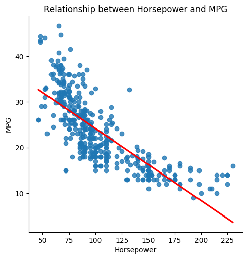

```python
# BEGIN SOLUTION
import matplotlib.pyplot as plt
sns.lmplot(x='horsepower', y='mpg', data=df, ci=None, line_kws={'color': 'red'})

# Set the labels and title
plt.xlabel('Horsepower')
plt.ylabel('MPG')
plt.title('Relationship between Horsepower and MPG')


# END SOLUTION
```

### c) Use the `plot_fit` function from statsmodels library to produce diagnostic plots of the least squares regression fit. Comment on any problems you see with the fit.

Link to plot_fit:

https://www.statsmodels.org/dev/generated/statsmodels.graphics.regressionplots.plot_fit.html

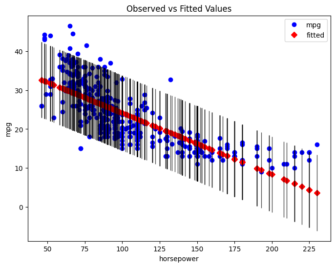

```python
# BEGIN SOLUTION
# Scatter plot of observed versus fitted values
fig, ax = plt.subplots(figsize=(8, 6))
sm.graphics.plot_fit(results, 1, ax=ax)
ax.set_title('Observed vs Fitted Values')
plt.show()
# END SOLUTION
```

## Question 5

This question involves the use of multiple linear regression on the Auto data set. Read the dataset first:

### a) Produce a scatterplot matrix using pairplot() from seaborn library which includes all of the variables in the data set

Link to pairplot: https://seaborn.pydata.org/generated/seaborn.pairplot.html

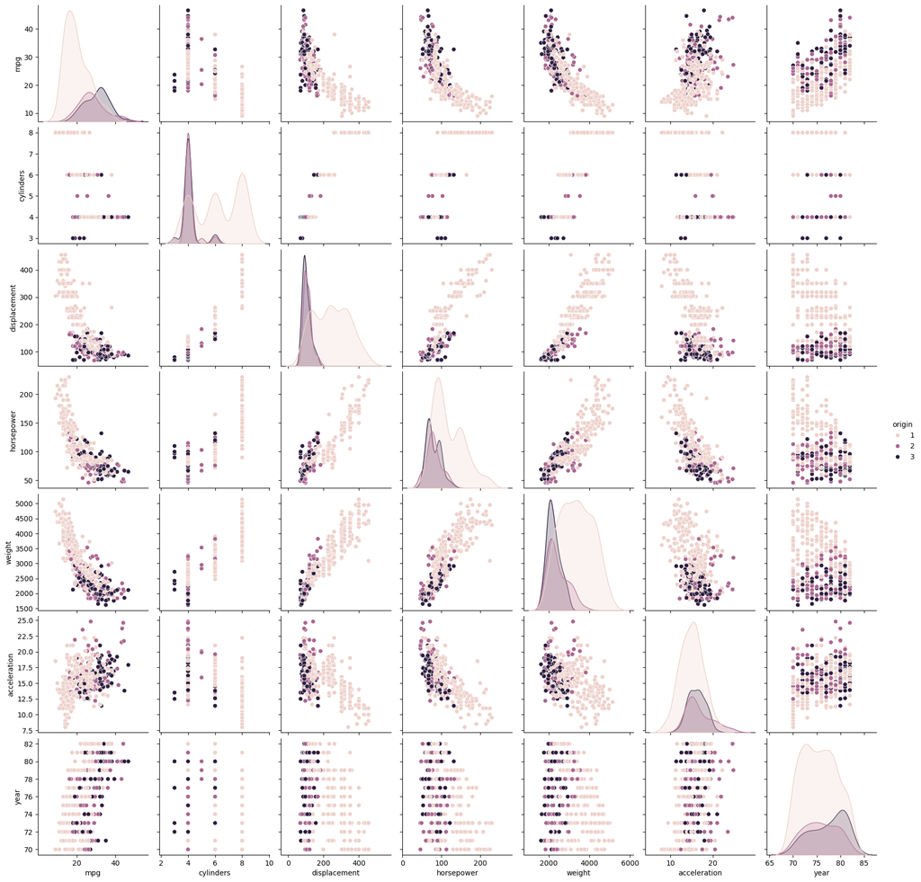

```python
# BEGIN SOLUTION
df = pd.read_csv('auto.csv')

df['horsepower'] = pd.to_numeric(df['horsepower'], errors='coerce')
df['horsepower'] = df['horsepower'].astype(float)

filtered_rows = df[df['horsepower'].isnull()]

average_horsepower_per_cylinder = df.groupby('cylinders')['horsepower'].transform('mean')
df['horsepower'] = df['horsepower'].fillna(average_horsepower_per_cylinder)

sns.pairplot(df, hue="origin")

# Show the plot
plt.show()


# END SOLUTION
```

### b) Compute the matrix of correlations between the variables using the function `corr()`in pandas on the dataframe also plot the corresponding correlation matrix using `heatmap` function in seaborn

Links:

Corr() : https://pandas.pydata.org/docs/reference/api/pandas.DataFrame.corr.html

Heatmap : https://seaborn.pydata.org/generated/seaborn.heatmap.html

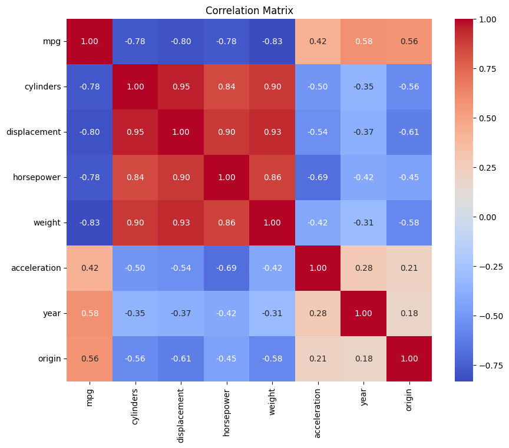

```python
# BEGIN SOLUTION
# I have to drop the non-numeric columns
numeric_columns = df.select_dtypes(include=['float64', 'int64'])
correlation_matrix = numeric_columns.corr()
# Plot the corresponding correlation matrix using heatmap
plt.figure(figsize=(10, 8))
sns.heatmap(correlation_matrix, annot=True, cmap='coolwarm', fmt=".2f", annot_kws={"size": 10})
plt.title('Correlation Matrix')
plt.show()
# END SOLUTION
```

**Positive Correlation:**

There is a strong positive correlation between mpg and year (0.581), indicating that newer cars tend to have higher miles per gallon. mpg also shows moderate positive correlations with origin (0.564) and acceleration (0.422).

**Negative Correlation:**

There are strong negative correlations between mpg and cylinders (-0.776), displacement (-0.804), horsepower (-0.776), and weight (-0.832). This suggests that cars with higher numbers of cylinders, larger engine displacements, more horsepower, and heavier weights tend to have lower miles per gallon.

### c) Use the `ols()` function from statsmodels library to perform a multiple linear regression with mpg as the response and all other variables except name as the predictors. Use the `summary()` function from statsmodels to print the results. Use the questions below to comment on the output.

Reference to Statsmodels library and ols :

https://www.statsmodels.org/dev/generated/statsmodels.regression.linear_model.OLS.html#generated-statsmodels-regression-linear-model-ols--page-root

Links to summary:

https://www.statsmodels.org/devel/generated/statsmodels.regression.linear_model.OLSResults.summary.html

```python
# BEGIN SOLUTION
y = df['mpg']  # Response variable
df = df.drop(columns=['name'])
X = df.drop(columns=['mpg'])
X = sm.add_constant(X)
model = sm.OLS(y, X)
results = model.fit()
print(results.summary())
# END SOLUTION
```

```
                            OLS Regression Results
==============================================================================
Dep. Variable:                    mpg   R-squared:                       0.822
Model:                            OLS   Adj. R-squared:                  0.819
Method:                 Least Squares   F-statistic:                     256.3
Date:                Sat, 30 Mar 2024   Prob (F-statistic):          1.91e-141
Time:                        12:14:24   Log-Likelihood:                -1037.2
No. Observations:                 397   AIC:                             2090.
Df Residuals:                     389   BIC:                             2122.
Df Model:                           7
Covariance Type:            nonrobust
================================================================================
                   coef    std err          t      P>|t|      [0.025      0.975]
--------------------------------------------------------------------------------
const          -18.1078      4.629     -3.912      0.000     -27.209      -9.006
cylinders       -0.4556      0.322     -1.413      0.158      -1.089       0.178
displacement     0.0196      0.008      2.605      0.010       0.005       0.034
horsepower      -0.0135      0.014     -0.984      0.326      -0.040       0.013
weight          -0.0066      0.001    -10.311      0.000      -0.008      -0.005
acceleration     0.1004      0.098      1.028      0.305      -0.092       0.293
year             0.7588      0.051     14.970      0.000       0.659       0.859
origin           1.4190      0.277      5.130      0.000       0.875       1.963
==============================================================================
Omnibus:                       30.078   Durbin-Watson:                   1.294
Prob(Omnibus):                  0.000   Jarque-Bera (JB):               48.286
Skew:                           0.511   Prob(JB):                     3.27e-11
Kurtosis:                       4.370   Cond. No.                     8.58e+04
==============================================================================

Notes:
[1] Standard Errors assume that the covariance matrix of the errors is correctly specified.
[2] The condition number is large, 8.58e+04. This might indicate that there are
strong multicollinearity or other numerical problems.
```

#### i. Is there a significant association between the predictors and the response?

Therefore, we can conclude that there is a significant association between some predictors (displacement, weight, year, origin) and the response variable (mpg), while others (cylinders, horsepower, acceleration) do not have a significant association.

#### ii. Which predictors appear to have a statistically significant relationship to the response?

In the provided regression results summary, we can observe the p-values (P>|t|) associated with each predictor variable:

```
cylinders: p-value = 0.158
displacement: p-value = 0.010
horsepower: p-value = 0.326
weight: p-value < 0.001
acceleration: p-value = 0.305
year: p-value < 0.001
origin: p-value < 0.001
Based on these p-values:
```

The predictors displacement, weight, year, and origin have p-values less than 0.05, indicating that they have a statistically significant association with mpg.

However, the predictors cylinders, horsepower, and acceleration have p-values greater than 0.05, suggesting that they do not have a statistically significant association with mpg at the conventional significance level of 0.05.

#### iii. What does the coefficient for the year variable suggest?

In the provided regression results summary, the coefficient for the year variable is 0.7588. This means that for every one-year increase in the model year of the car, the predicted mpg value is expected to increase by approximately 0.7588 units, all else being equal.

A positive coefficient indicates that newer cars tend to have higher fuel efficiency, as measured by miles per gallon (mpg). The magnitude of the coefficient (0.7588) suggests that, on average, each additional year of car production is associated with an increase in mpg by approximately 0.7588 units.

This finding is consistent with the general expectation that advancements in automotive technology, engine efficiency, and emissions standards over time lead to improvements in fuel efficiency.

### d) Use the `plot_fit ()` function from statsmodels to produce diagnostic plots of the linear regression fit. Again, feel free to use any other package or function to create these plots. Comment on any problems you see with the fit. Do the residual plots suggest any unusually large outliers? Does the leverage plot identify any observations with unusually high leverage?

Link to plot_fit:

https://www.statsmodels.org/dev/generated/statsmodels.graphics.regressionplots.plot_fit.html

Link to residual plots:

https://www.statsmodels.org/dev/generated/statsmodels.graphics.regressionplots.plot_leverage_resid2.html

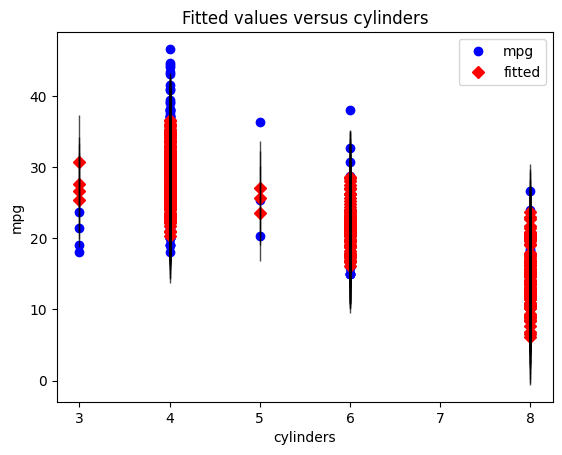

```python
# Produce diagnostic plots of the linear regression fit
import statsmodels.api as sm
from statsmodels.graphics.regressionplots import plot_fit

# Generate diagnostic plots
plot_fit(results, 1)

# Show the plots
plt.show()
```

## Comments

- I did not observe any problem with the fit.
- I see some outliers as well but regression fit looks fine

```python
#using plot_leverage_resid2
```

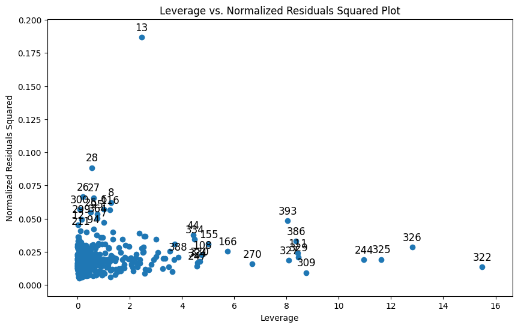

```python
# BEGIN SOLUTION
fig, ax = plt.subplots(figsize=(10, 6))
sm.graphics.plot_leverage_resid2(results, ax=ax)

# Set plot labels and title
ax.set_xlabel("Leverage")
ax.set_ylabel("Normalized Residuals Squared")
ax.set_title("Leverage vs. Normalized Residuals Squared Plot")


# END SOLUTION
```

### e) Fit a linear regression model with interaction effects. explore a few different models (~3–4 models). Do any interactions appear to be statistically significant in any of the models you examined?

Use formula.ols to check the interaction between two predictors as used in the below reference link

https://www.statsmodels.org/devel/example_formulas.html

```python
# BEGIN SOLUTION

model_interaction_1 = sm.OLS.from_formula('mpg ~ cylinders * displacement', data=df)
results_interaction_1 = model_interaction_1.fit()
print(results_interaction_1.summary())

# Model 2: Interaction between cylinders and horsepower
model_interaction_2 = sm.OLS.from_formula('mpg ~ cylinders * horsepower', data=df)
results_interaction_2 = model_interaction_2.fit()
print(results_interaction_2.summary())

# Model 3: Interaction between displacement and horsepower
model_interaction_3 = sm.OLS.from_formula('mpg ~ displacement * horsepower', data=df)
results_interaction_3 = model_interaction_3.fit()
print(results_interaction_3.summary())

# Model 4: Interaction between cylinders, displacement, and horsepower
model_interaction_4 = sm.OLS.from_formula('mpg ~ cylinders * displacement * horsepower', data=df)
results_interaction_4 = model_interaction_4.fit()
print(results_interaction_4.summary())

# END SOLUTION
```

```
                            OLS Regression Results
==============================================================================
Dep. Variable:                    mpg   R-squared:                       0.677
Model:                            OLS   Adj. R-squared:                  0.674
Method:                 Least Squares   F-statistic:                     274.0
Date:                Sat, 30 Mar 2024   Prob (F-statistic):           6.23e-96
Time:                        12:14:25   Log-Likelihood:                -1155.6
No. Observations:                 397   AIC:                             2319.
Df Residuals:                     393   BIC:                             2335.
Df Model:                           3
Covariance Type:            nonrobust
==========================================================================================
                             coef    std err          t      P>|t|      [0.025      0.975]
------------------------------------------------------------------------------------------
Intercept                 48.4355      2.341     20.687      0.000      43.832      53.039
cylinders                 -2.4226      0.534     -4.535      0.000      -3.473      -1.372
displacement              -0.1368      0.016     -8.490      0.000      -0.169      -0.105
cylinders:displacement     0.0121      0.002      5.841      0.000       0.008       0.016
==============================================================================
Omnibus:                       41.447   Durbin-Watson:                   0.950
Prob(Omnibus):                  0.000   Jarque-Bera (JB):              103.714
Skew:                           0.515   Prob(JB):                     3.01e-23
Kurtosis:                       5.283   Cond. No.                     1.70e+04
==============================================================================

Notes:
[1] Standard Errors assume that the covariance matrix of the errors is correctly specified.
[2] The condition number is large, 1.7e+04. This might indicate that there are
strong multicollinearity or other numerical problems.
                            OLS Regression Results
==============================================================================
Dep. Variable:                    mpg   R-squared:                       0.723
Model:                            OLS   Adj. R-squared:                  0.721
Method:                 Least Squares   F-statistic:                     341.9
Date:                Sat, 30 Mar 2024   Prob (F-statistic):          3.79e-109
Time:                        12:14:25   Log-Likelihood:                -1124.8
No. Observations:                 397   AIC:                             2258.
Df Residuals:                     393   BIC:                             2274.
Df Model:                           3
Covariance Type:            nonrobust
```

[output cut: 65 more lines]

```
horsepower                           -0.4589      0.120     -3.829      0.000      -0.694      -0.223
cylinders:horsepower                  0.0333      0.020      1.700      0.090      -0.005       0.072
displacement:horsepower               0.0023      0.001      2.595      0.010       0.001       0.004
cylinders:displacement:horsepower    -0.0002      0.000     -2.031      0.043      -0.000   -7.54e-06
==============================================================================
Omnibus:                       49.896   Durbin-Watson:                   1.053
Prob(Omnibus):                  0.000   Jarque-Bera (JB):              107.913
Skew:                           0.672   Prob(JB):                     3.69e-24
Kurtosis:                       5.171   Cond. No.                     1.50e+07
==============================================================================

Notes:
[1] Standard Errors assume that the covariance matrix of the errors is correctly specified.
[2] The condition number is large, 1.5e+07. This might indicate that there are
strong multicollinearity or other numerical problems.
```

## Observations

We can observe the coefficients and p-values associated with the interaction terms in each model:

### Model 1:

Interaction between cylinders and displacement: Coefficient = 0.0121, p-value < 0.001

### Model 2:

Interaction between cylinders and horsepower: Coefficient = 0.0473, p-value < 0.001

### Model 3:

Interaction between displacement and horsepower: Coefficient = 0.0006, p-value < 0.001

### f) Try a few different transformations of the variables, such as `log(X)`, `sqrt(X)`, $X^2$. Comment on your findings.

```python
# BEGIN SOLUTION

import numpy as np
import statsmodels.api as sm

# Example transformation: Log transformation
df['log_displacement'] = np.log(df['displacement'])

# Model with log transformation
model_log_transformation = sm.OLS.from_formula('mpg ~ cylinders + log_displacement + horsepower', data=df)
results_log_transformation = model_log_transformation.fit()
print(results_log_transformation.summary())

# Square root transformation
df['sqrt_displacement'] = np.sqrt(df['displacement'])

# Model with square root transformation
model_sqrt_transformation = sm.OLS.from_formula('mpg ~ cylinders + sqrt_displacement + horsepower', data=df)
results_sqrt_transformation = model_sqrt_transformation.fit()
print(results_sqrt_transformation.summary())

# Reciprocal transformation
df['reciprocal_displacement'] = 1 / df['displacement']

# Model with reciprocal transformation
model_reciprocal_transformation = sm.OLS.from_formula('mpg ~ cylinders + reciprocal_displacement + horsepower', data=df)
results_reciprocal_transformation = model_reciprocal_transformation.fit()
print(results_reciprocal_transformation.summary())


# END SOLUTION
```

```
                            OLS Regression Results
==============================================================================
Dep. Variable:                    mpg   R-squared:                       0.706
Model:                            OLS   Adj. R-squared:                  0.703
Method:                 Least Squares   F-statistic:                     313.9
Date:                Sat, 30 Mar 2024   Prob (F-statistic):          6.14e-104
Time:                        12:14:25   Log-Likelihood:                -1136.9
No. Observations:                 397   AIC:                             2282.
Df Residuals:                     393   BIC:                             2298.
Df Model:                           3
Covariance Type:            nonrobust
====================================================================================
                       coef    std err          t      P>|t|      [0.025      0.975]
------------------------------------------------------------------------------------
Intercept           80.4562      4.552     17.675      0.000      71.507      89.405
cylinders            0.6227      0.387      1.610      0.108      -0.138       1.383
log_displacement   -10.6485      1.279     -8.324      0.000     -13.163      -8.133
horsepower          -0.0555      0.011     -5.032      0.000      -0.077      -0.034
==============================================================================
Omnibus:                       36.222   Durbin-Watson:                   0.952
Prob(Omnibus):                  0.000   Jarque-Bera (JB):               54.427
Skew:                           0.624   Prob(JB):                     1.52e-12
Kurtosis:                       4.317   Cond. No.                     2.46e+03
==============================================================================

Notes:
[1] Standard Errors assume that the covariance matrix of the errors is correctly specified.
[2] The condition number is large, 2.46e+03. This might indicate that there are
strong multicollinearity or other numerical problems.
                            OLS Regression Results
==============================================================================
Dep. Variable:                    mpg   R-squared:                       0.688
Model:                            OLS   Adj. R-squared:                  0.685
Method:                 Least Squares   F-statistic:                     288.3
Date:                Sat, 30 Mar 2024   Prob (F-statistic):           6.97e-99
Time:                        12:14:25   Log-Likelihood:                -1148.7
No. Observations:                 397   AIC:                             2305.
Df Residuals:                     393   BIC:                             2321.
Df Model:                           3
Covariance Type:            nonrobust
```

[output cut: 30 more lines]

```
Intercept                  23.0232      2.397      9.606      0.000      18.311      27.735
cylinders                  -0.1009      0.313     -0.322      0.748      -0.717       0.515
reciprocal_displacement  1239.9753    141.709      8.750      0.000     961.373    1518.578
horsepower                 -0.0708      0.010     -6.768      0.000      -0.091      -0.050
==============================================================================
Omnibus:                       31.414   Durbin-Watson:                   0.995
Prob(Omnibus):                  0.000   Jarque-Bera (JB):               56.792
Skew:                           0.488   Prob(JB):                     4.65e-13
Kurtosis:                       4.574   Cond. No.                     7.42e+04
==============================================================================

Notes:
[1] Standard Errors assume that the covariance matrix of the errors is correctly specified.
[2] The condition number is large, 7.42e+04. This might indicate that there are
strong multicollinearity or other numerical problems.
```

Based on the results of the different transformations applied to the variables in the linear regression models:

1. **Log Transformation Model**:
   - R-squared: 0.706
   - Coefficients:
     - Intercept: 80.4562
     - cylinders: 0.6227
     - log_displacement: -10.6485
     - horsepower: -0.0555
   - The log transformation of displacement appears to be statistically significant (p-value < 0.05), indicating that it improves the model fit compared to the model without transformation. However, cylinders are not statistically significant (p-value > 0.05).
2. **Square Root Transformation Model**:
   - R-squared: 0.688
   - Coefficients:
     - Intercept: 46.4387
     - cylinders: 0.3805
     - sqrt_displacement: -1.4802
     - horsepower: -0.0492
   - The square root transformation of displacement also shows statistical significance (p-value < 0.05), suggesting an improvement in the model fit. However, cylinders remain statistically insignificant (p-value > 0.05).
3. **Reciprocal Transformation Model**:
   - R-squared: 0.710
   - Coefficients:
     - Intercept: 23.0232
     - cylinders: -0.1009
     - reciprocal_displacement: 1239.9753
     - horsepower: -0.0708
   - The reciprocal transformation of displacement is statistically significant (p-value < 0.05), indicating a better model fit. However, cylinders remain statistically insignificant (p-value > 0.05).

Overall, the log and square root transformations of displacement seem to improve the model fit, as indicated by their statistical significance. However, cylinders still appear to be insignificant in all models. This could suggest that the relationship between cylinders and mpg is not adequately captured by a linear relationship in these models.

## Question 6

In this exercise you will create some simulated data and will fit simple linear regression models to it. Make sure to use `set.seed(1)` prior to starting part (a) to ensure consistent results.

### a) Using the random normal function, create a vector, `x`, containing 100 observations drawn from a $N(0, 1)$ distribution. This represents a feature, `X`.

Link to random normal function: https://numpy.org/doc/stable/reference/random/generated/numpy.random.normal.html

```python
# BEGIN SOLUTION
import numpy as np

# Set the seed for reproducibility
np.random.seed(1)

# Create the vector x containing 100 observations drawn from N(0, 1)
x = np.random.normal(loc=0, scale=1, size=100)
# END SOLUTION
```

### b) Using the `random normal` function, create a vector, `eps`, containing 100 observations drawn from a $N(0, 0.25)$ distribution — a normal distribution with mean zero and variance `0.25`.

Link to random normal function: https://numpy.org/doc/stable/reference/random/generated/numpy.random.normal.html

```python
# BEGIN SOLUTION
eps = np.random.normal(loc=0, scale=0.25, size=100)
# END SOLUTION
```

### c) Using `x` and `eps`, generate a vector `y` according to the model $Y = -1 + 0.5X + ϵ$. What is the length of the vector `y`? What are the values of $β_0$ and $β_1$ in this linear model?

```python
# BEGIN SOLUTION

y = -1 + 0.5 * x + eps
length_y = len(y)
print(length_y)
# END SOLUTION
```

```
100
```

length_y = 100

$β_0$ = -1

$β_1$ = 0.5

### d) Create a scatterplot displaying the relationship between `x` and `y`. Comment on what you observe.

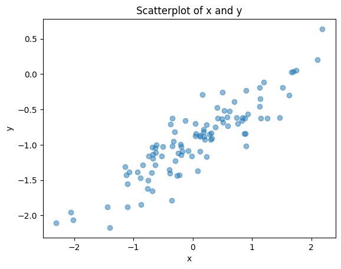

```python
# BEGIN SOLUTION
import matplotlib.pyplot as plt

# Create scatterplot
plt.scatter(x, y, alpha=0.5)
plt.title('Scatterplot of x and y')
plt.xlabel('x')
plt.ylabel('y')
plt.show()
# END SOLUTION
```

Observations:

- As relationship is linear we see a scatterplot is having linear relationship.
- We see some noise due to ϵ.
- It roughly follows the slope of 0.5 and intercept of -1 as per given model equation.

### e) Fit a least squares linear model that relates y and `x`. Comment on the model obtained. How do the estimated coefficients (slope and intercept) compare to the true values used to simulate the data?

```python
# BEGIN SOLUTION
import statsmodels.api as sm

x_with_intercept = sm.add_constant(x)
model = sm.OLS(y, x_with_intercept)
results = model.fit()
print(results.summary())
# END SOLUTION
```

```
                            OLS Regression Results
==============================================================================
Dep. Variable:                      y   R-squared:                       0.800
Model:                            OLS   Adj. R-squared:                  0.798
Method:                 Least Squares   F-statistic:                     391.4
Date:                Sat, 30 Mar 2024   Prob (F-statistic):           5.39e-36
Time:                        12:14:25   Log-Likelihood:                 4.1908
No. Observations:                 100   AIC:                            -4.382
Df Residuals:                      98   BIC:                            0.8288
Df Model:                           1
Covariance Type:            nonrobust
==============================================================================
                 coef    std err          t      P>|t|      [0.025      0.975]
------------------------------------------------------------------------------
const         -0.9632      0.023    -40.999      0.000      -1.010      -0.917
x1             0.5239      0.026     19.783      0.000       0.471       0.576
==============================================================================
Omnibus:                        0.898   Durbin-Watson:                   2.157
Prob(Omnibus):                  0.638   Jarque-Bera (JB):                0.561
Skew:                          -0.172   Prob(JB):                        0.755
Kurtosis:                       3.127   Cond. No.                         1.15
==============================================================================

Notes:
[1] Standard Errors assume that the covariance matrix of the errors is correctly specified.
```

Observations on the OLS regression results:

Overall, the regression results indicate that the model is a good fit for the data, and both the intercept and the coefficient for `x` are statistically significant in explaining the variation in `y`.